# Exercise 2: Group 10, Jafre13

Accuracy function which will be used later

```r
accuracy <- function(results,testlabels) {
  count = 0
  for (i in 1:length(results)){
    if (results[i]==testlabels[i]){
      count = count+1
    }
  }
  return((count/length(results))*100)

}
```

1.1 First load the data into a dataframe

```r
source('C:/SML/PCA/loadImage.R')
library("caret")
rawdata1 = loadSinglePersonsData(100,"group10",1,"C:/SMLIMAGES/2017/")
rawdata2 = loadSinglePersonsData(100,"group12",1,"C:/SMLIMAGES/2017/")
```

Shuffling the data for two persons independent and dependendent, and extracting labels from dataset

```r
p1 = data.frame(rawdata1)
p2 = data.frame(rawdata2)

combined = rbind(rawdata1,rawdata2)
doTheShuffle <- function(){
  independent <<- data.frame(combined)
  shuffled_inde <<- independent[sample(nrow(independent)),]
  independent_labels <<- shuffled_inde$X1
  shuffled_inde <<- subset(shuffled_inde,select = -c(X1))
}

p1_shuff = p1[sample(nrow(p1)),]
p2_shuff = p2[sample(nrow(p2)),]

doTheShuffle()

p1_labels = p1_shuff$X1
p1_shuff = subset(p1_shuff,select = -c(X1))
p2_labels = p2_shuff$X1
p2_shuff = subset(p2_shuff,select = -c(X1))
```

Performing independent PCA with first 4000 entries, the other 4000 will be used for testing

```r
inde_pca <- prcomp(shuffled_inde[1:4000,])
vari = (((inde_pca$sdev)^2)*100)/sum((inde_pca$sdev)^2)
cs = cumsum(vari)
```

Standard deviation:

```r
head(inde_pca$sdev,n=10)
```

```
##  [1] 1.1837813 0.9877413 0.6167215 0.5858691 0.5582592 0.5257345 0.4905580
##  [8] 0.4526491 0.4203055 0.3977759
```

Variance

```r
head(vari,n=10)
```

```
##  [1] 21.647630 15.071409  5.875510  5.302353  4.814368  4.269729  3.717476
##  [8]  3.165125  2.728963  2.444243
```

Cumsum Variance

```r
head(cs,n=41)
```

```
##  [1] 21.64763 36.71904 42.59455 47.89690 52.71127 56.98100 60.69847
##  [8] 63.86360 66.59256 69.03680 71.27077 73.26589 75.10510 76.75268
## [15] 78.37166 79.83483 81.21934 82.49283 83.62854 84.65490 85.66003
## [22] 86.59161 87.47346 88.30410 89.02274 89.72352 90.39678 90.98283
## [29] 91.52506 92.06058 92.55638 93.03249 93.44152 93.81503 94.16740
## [36] 94.48570 94.79437 95.08200 95.36135 95.62348 95.86783
```

Some quick plots of variance and cumsum

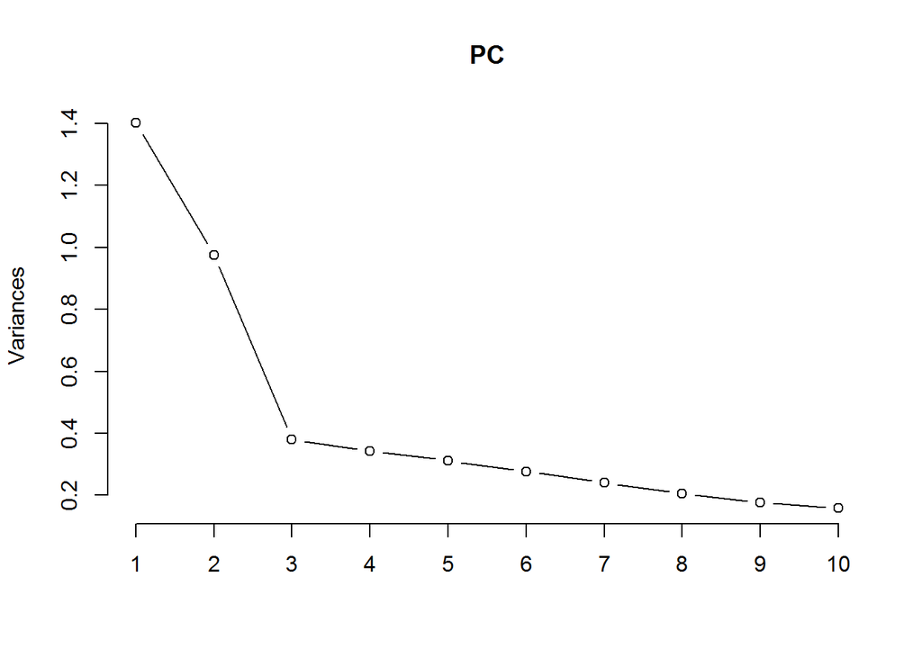

```r
plot(inde_pca,type="l",xlab("PC"))
```

The Cummulative variance

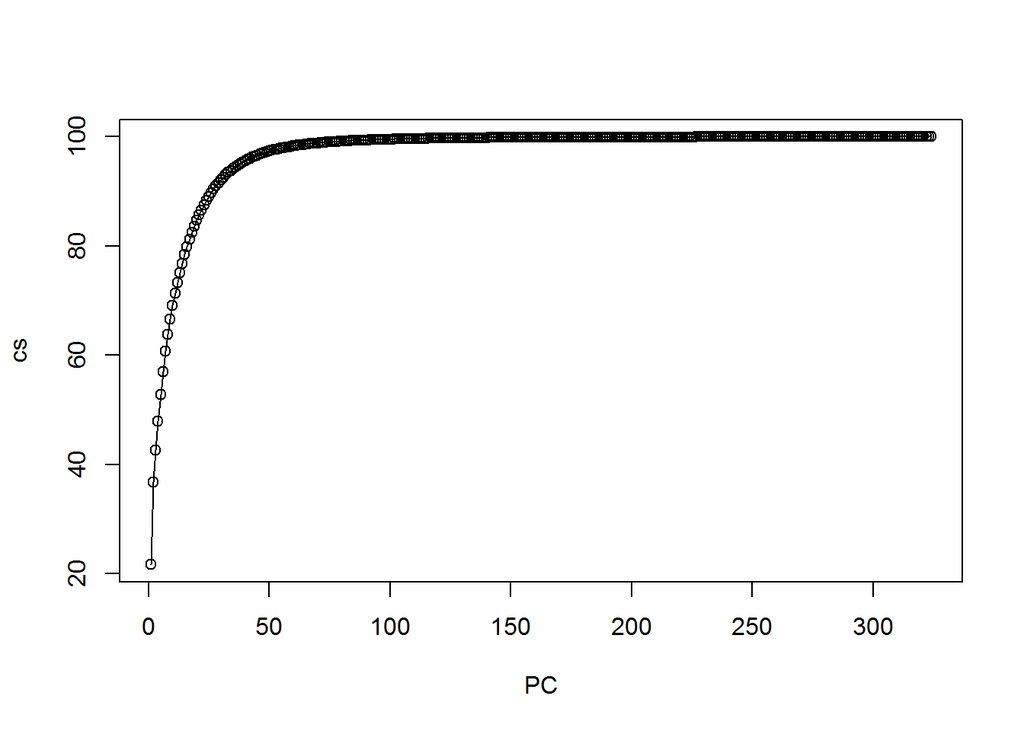

```r
plot(cs,type="o",xlab="PC")
```

```r
train = inde_pca$x
trainlabels = independent_labels[1:4000]
test = predict(inde_pca,shuffled_inde[4001:8000,])
indeAcc = c()
indeTime = c()

testlabels = independent_labels[4001:8000]
variances = c(16,27,38,74)
print(variances)
```

```
## [1] 16 27 38 74
```

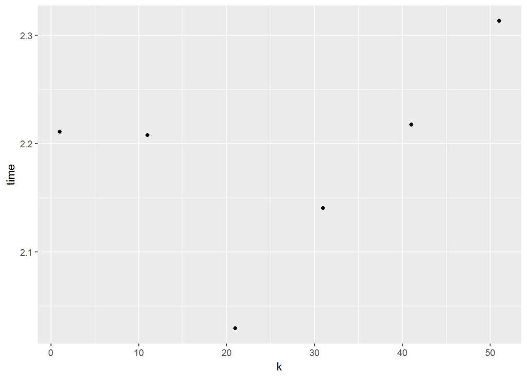

```r
k = seq(from=1,to=51,by=10)
for (j in variances){
  time = c()
  acc = c()
  for (i in k){
    startTime = Sys.time()
    results = knn(train[,1:j],test[,1:j],k=i,cl = trainlabels)
    endtime = Sys.time()
    time=c(time,(endtime-startTime))
    acc = c(acc,accuracy(results,testlabels))
  }

  indeTime = c(indeTime,time[1])
  indeAcc = c(indeAcc,acc[1])
}
qplot(k,time)
```

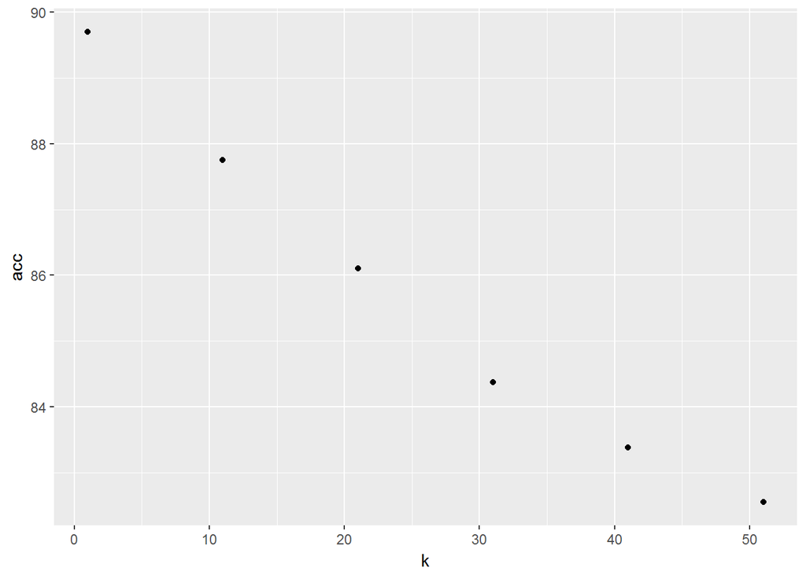

```r
qplot(k,acc)
```

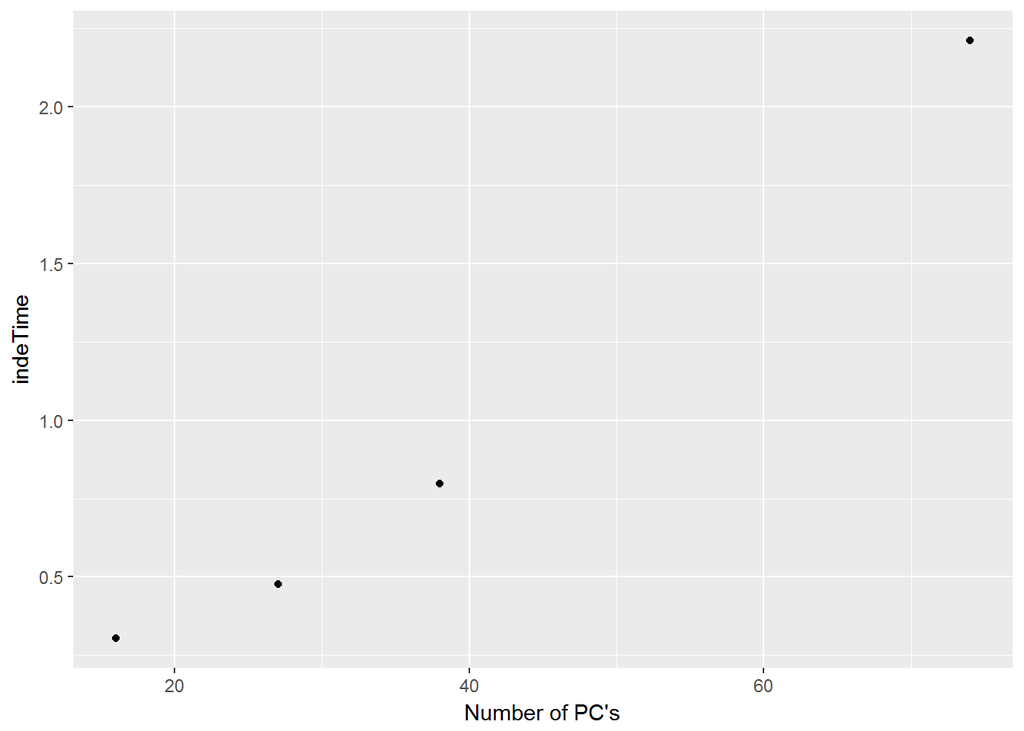

```r
qplot(variances,indeTime,xlab ="Number of PC's")
```

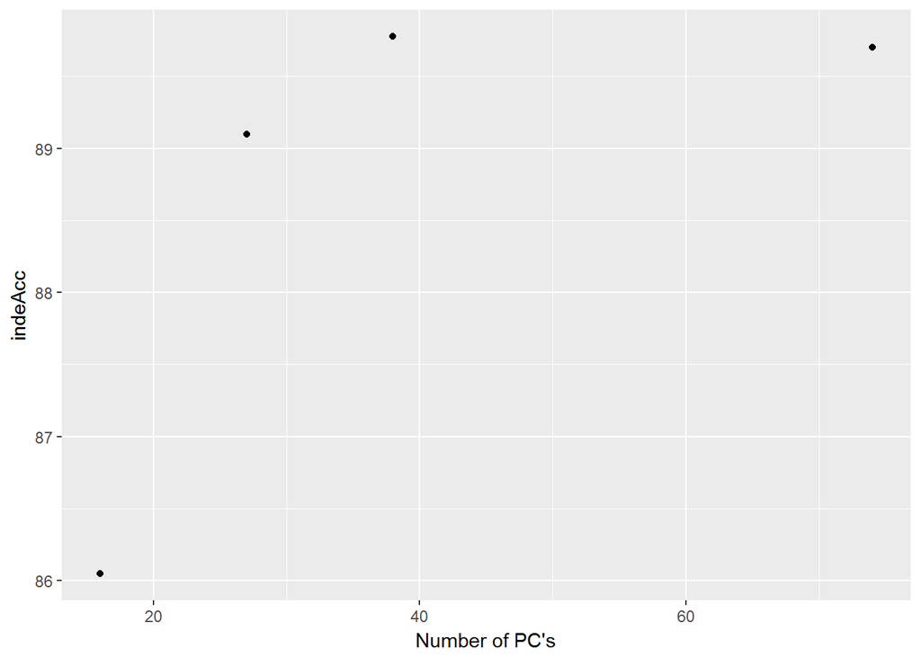

```r
qplot(variances,indeAcc,xlab ="Number of PC's")
```

no to do it with person dependent data. This section hasn’t provided great answers as i chose to only use 2 persons data to save computational time. this could explain the low percentage of correct predictions due to us writing digits fairly different

```r
p1_pca <- prcomp(p1_shuff)
vari = (((p1_pca$sdev)^2)*100)/sum((p1_pca$sdev)^2)
```

```r
train = p1_pca$x
trainlabels = p1_labels
test = predict(p1_pca,p2_shuff)
pacc = c()
ptime = c()

testlabels = p2_labels
variances = c(18,29,41,76)
print(variances)
```

```
## [1] 18 29 41 76
```

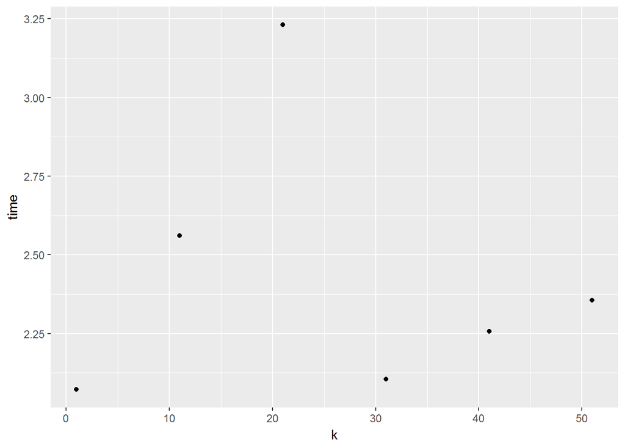

```r
k = seq(from=1,to=51,by=10)
for (j in variances){
  time = c()
  acc = c()
  for (i in k){
    startTime = Sys.time()
    results = knn(train[,1:j],test[,1:j],k=i,cl = trainlabels)
    endtime = Sys.time()
    time=c(time,(endtime-startTime))
    acc = c(acc,accuracy(results,testlabels))
  }

  qplot(k,time)
  qplot(k,acc)
  ptime = c(ptime,time[1])
  pacc = c(pacc,acc[1])
}
qplot(k,time)
```

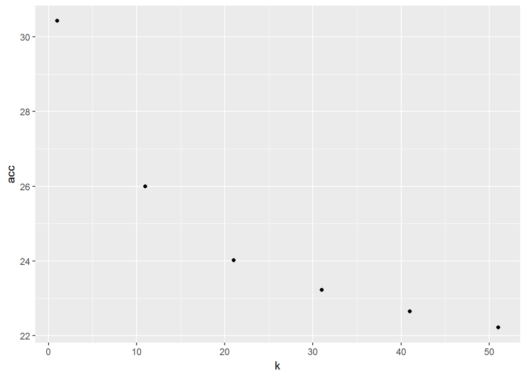

```r
qplot(k,acc)
```

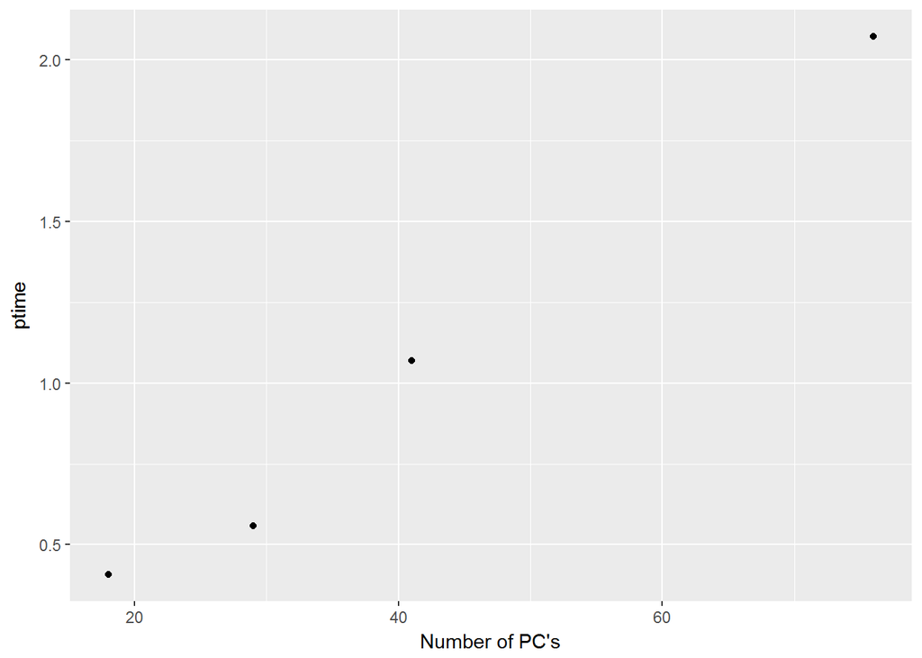

```r
qplot(variances,ptime,xlab ="Number of PC's")
```

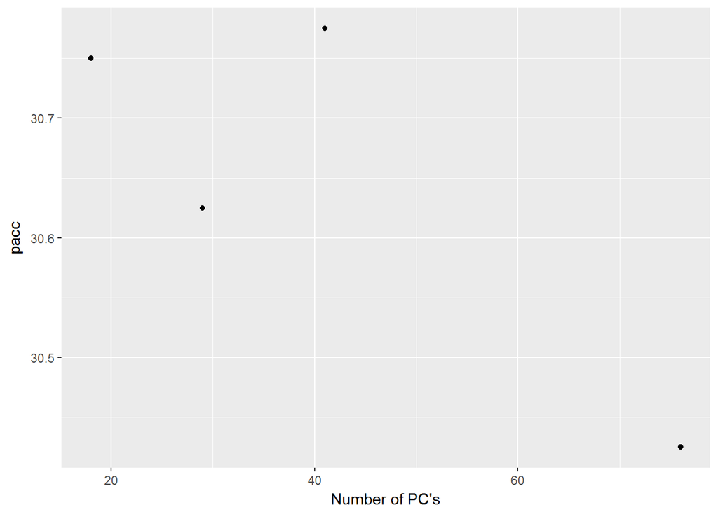

```r
qplot(variances,pacc,xlab ="Number of PC's")
```

using scale and center arguments for normalization and standardization i decided to use the built in function for scale and centering which as far as i understood, should handle normalization and standardization of the data, i tried by applying my own functions to this, but something went wrong, and i ended up with knn only guessing at 1’s.

```r
indeAcc = c()
indeTime = c()


k = seq(from=1,to=51,by=10)

time = c()
acc = c()
for (i in 1:10){
  doTheShuffle()
  standard_inde = as.data.frame((shuffled_inde))
  stand_pca = prcomp(standard_inde[1:7200,], scale. = TRUE, center = TRUE)
  train = stand_pca$x
  trainlabels = independent_labels[1:7200]
  test = predict(stand_pca,shuffled_inde[7201:8000,])
  testlabels = independent_labels[7201:8000]

  startTime = Sys.time()
  results = knn(train[,1:41],test[,1:41],k=1,cl = trainlabels)

  endtime = Sys.time()
  time=c(time,(endtime-startTime))
  acc = c(acc,accuracy(results,testlabels))
  indeTime = c(indeTime,mean(time))
  indeAcc = c(indeAcc,mean(acc))
}

print(mean(indeTime))
```

```
## [1] 0.5297246
```

```r
print(mean(indeAcc))
```

```
## [1] 90.5133
```

normalazing and standardizing after pca

```r
indeAcc = c()
indeTime = c()

print(variances)
```

```
## [1] 18 29 41 76
```

```r
k = seq(from=1,to=51,by=10)

time = c()
acc = c()
for (i in 1:10){
  doTheShuffle()
  standard_inde = as.data.frame((shuffled_inde))
  stand_pca = prcomp(standard_inde[1:7200,])
  train = scale(stand_pca$x)
  trainlabels = independent_labels[1:7200]
  test = scale(predict(stand_pca,shuffled_inde[7201:8000,]))
  testlabels = independent_labels[7201:8000]

  startTime = Sys.time()
  results = knn(train[,1:41],test[,1:41],k=1,cl = trainlabels)

  endtime = Sys.time()
  time=c(time,(endtime-startTime))
  acc = c(acc,accuracy(results,testlabels))
  indeTime = c(indeTime,mean(time))
  indeAcc = c(indeAcc,mean(acc))
}

print(mean(indeTime))
```

```
## [1] 0.6156646
```

```r
print(mean(indeAcc))
```

```
## [1] 88.00452
```

when applying after pca, we can see that we loose a small amount of accuracy, while time taken also rises.

Reconstruction

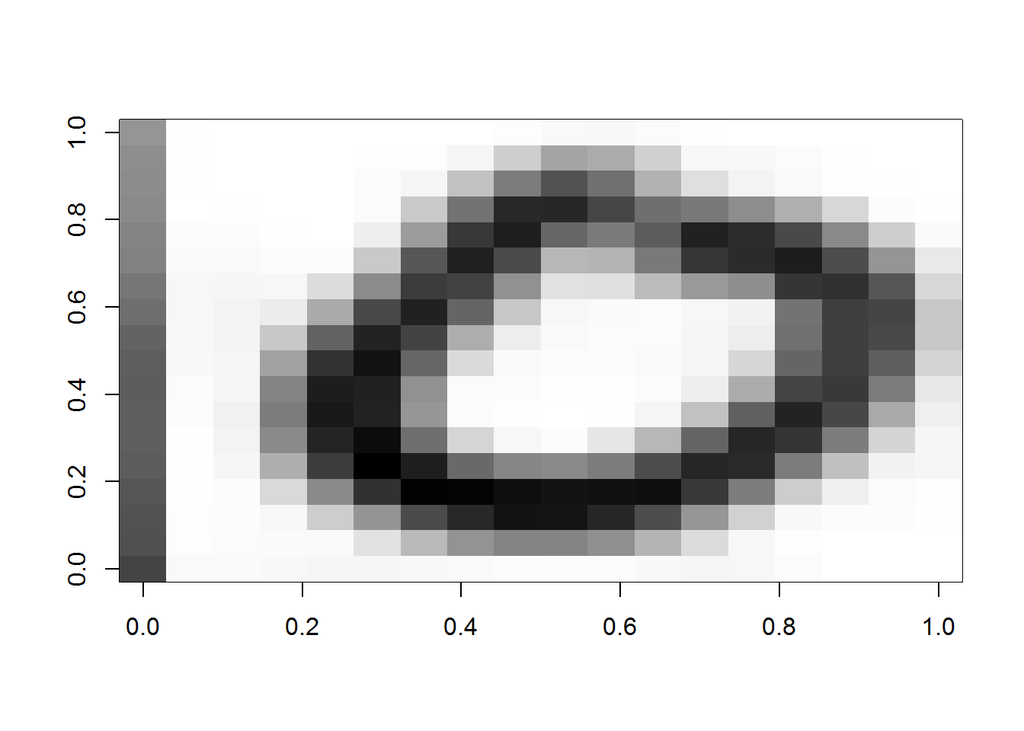

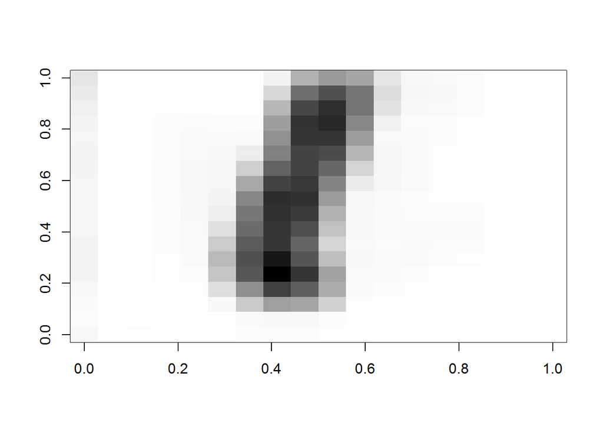

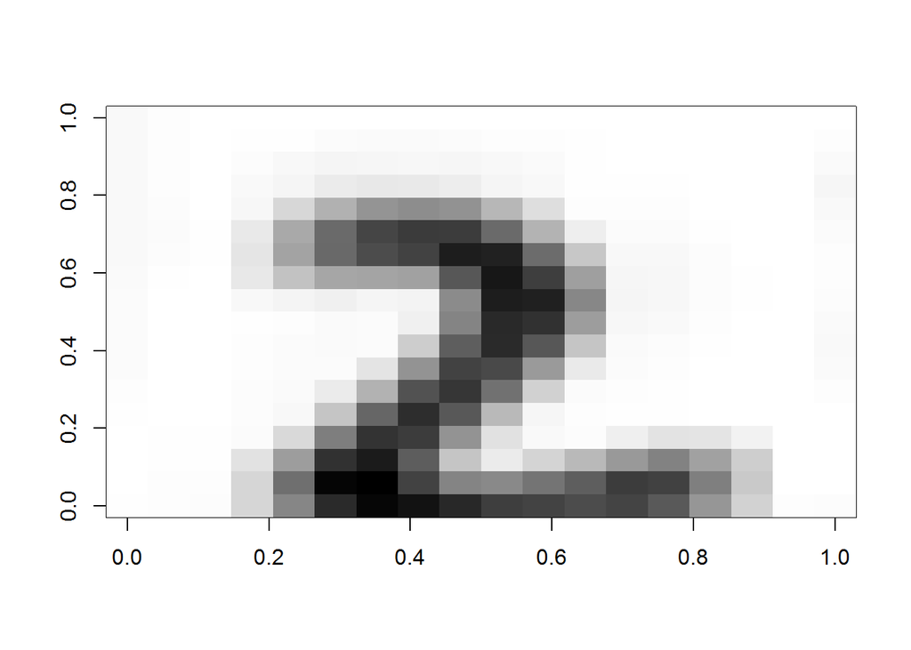

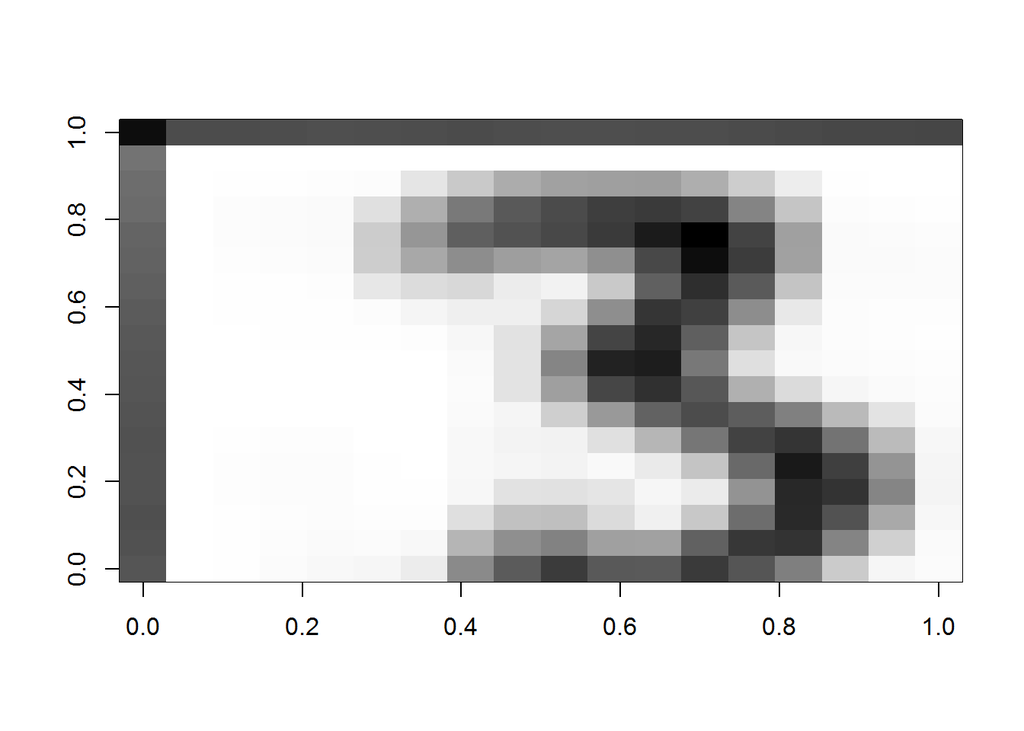

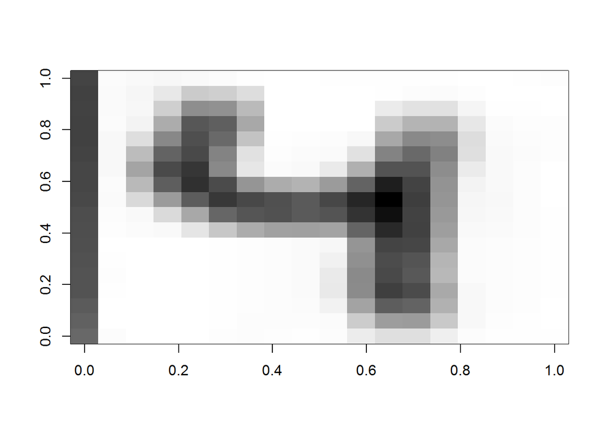

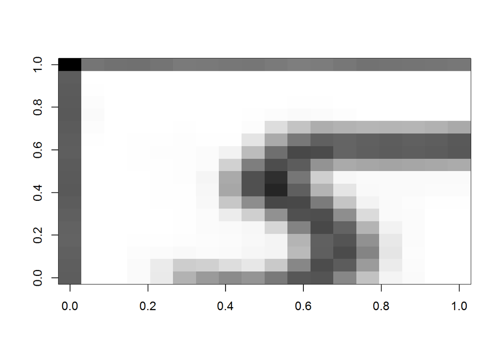

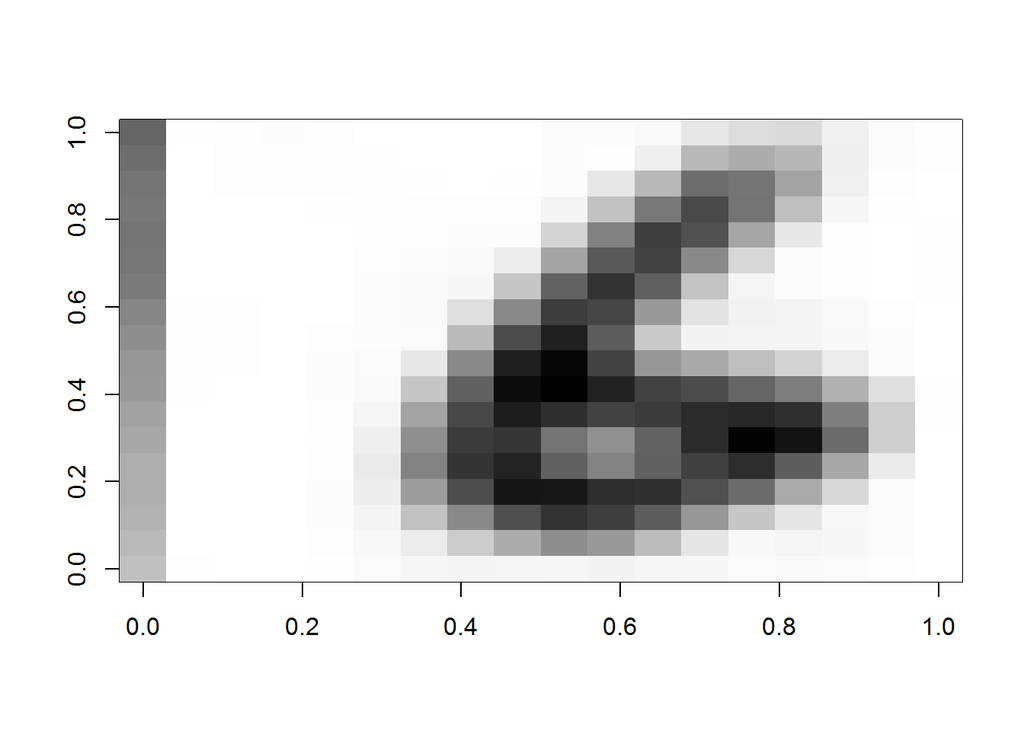

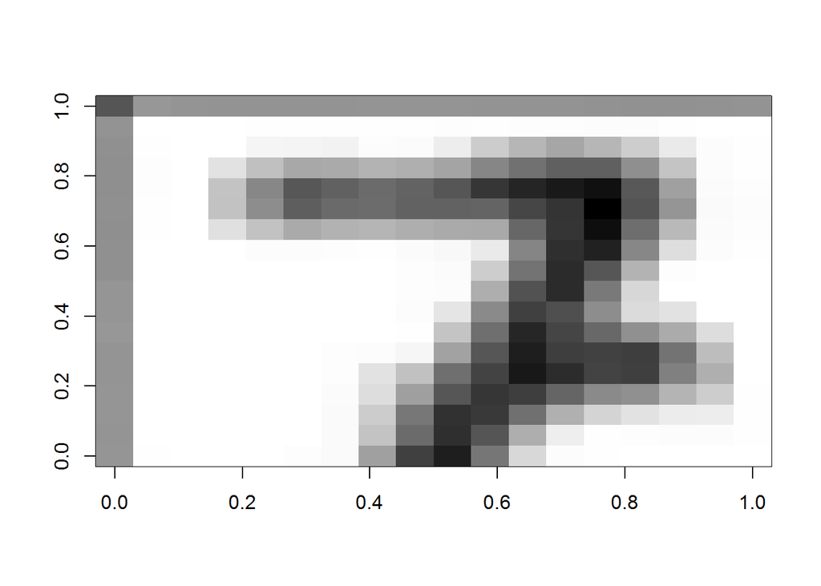

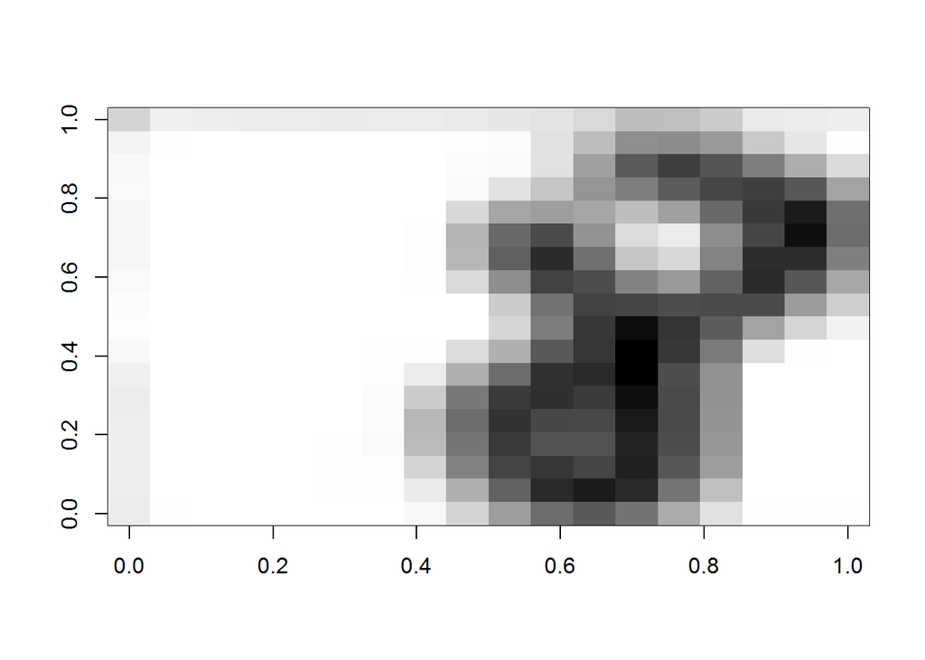

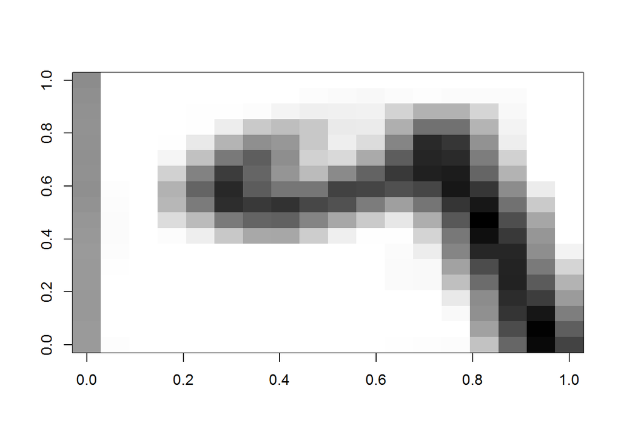

```r
for (i in 0:9){
  imageSize = sqrt(ncol(p1)-1)
  imageMatrix <- matrix( p1[1+i*400,2:ncol(p1)], nrow = imageSize, ncol=imageSize, byrow= FALSE)
  imageMatrix <- rotate(imageMatrix, 270)
  image(imageMatrix, col=gray((0:255)/255))

}
```

When printing out the images, it can be seen that the corners might not have been set properly, which could provide more details at to why some accuracy percentages have been low.

```r
ncol(p1_pca$x)-1
```

```
## [1] 323
```

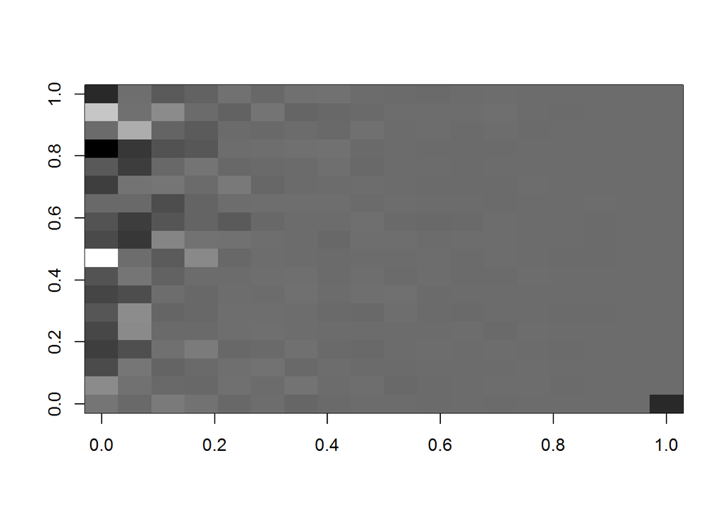

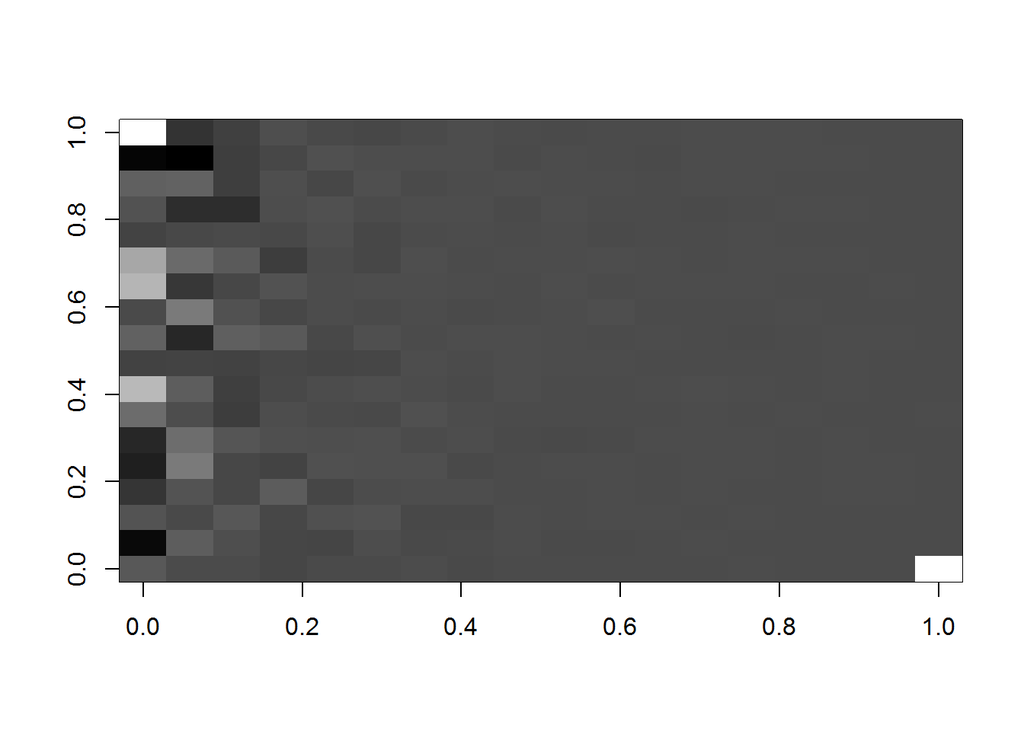

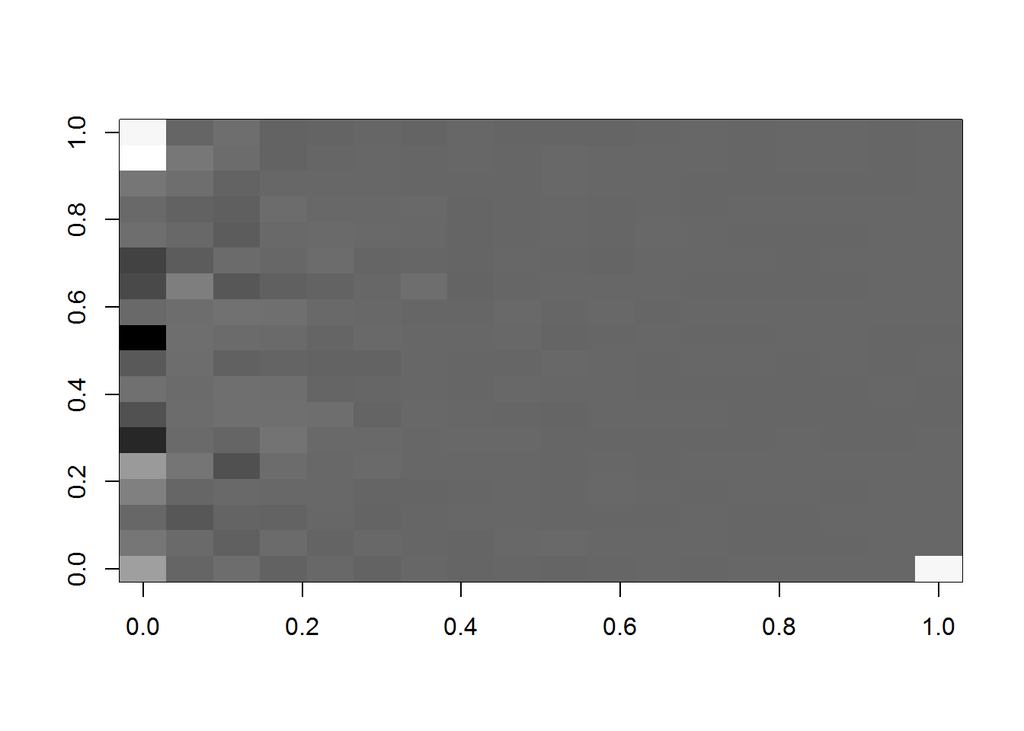

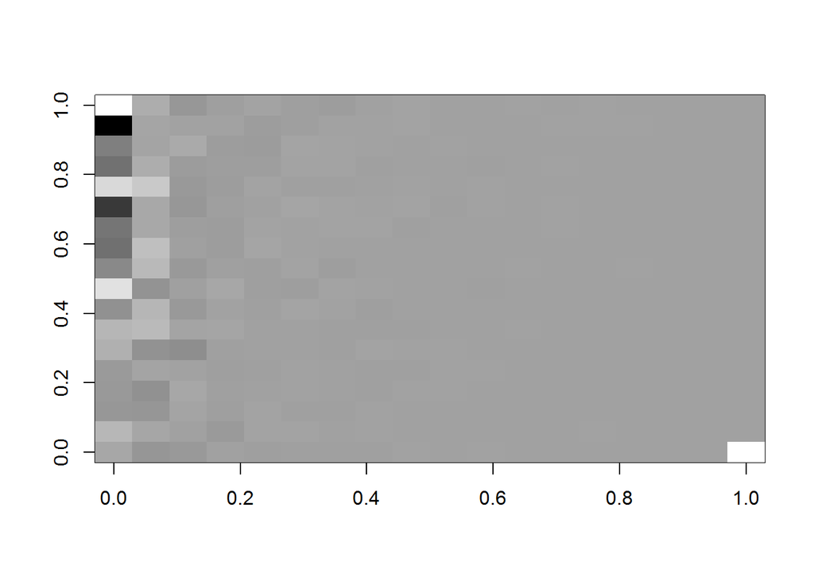

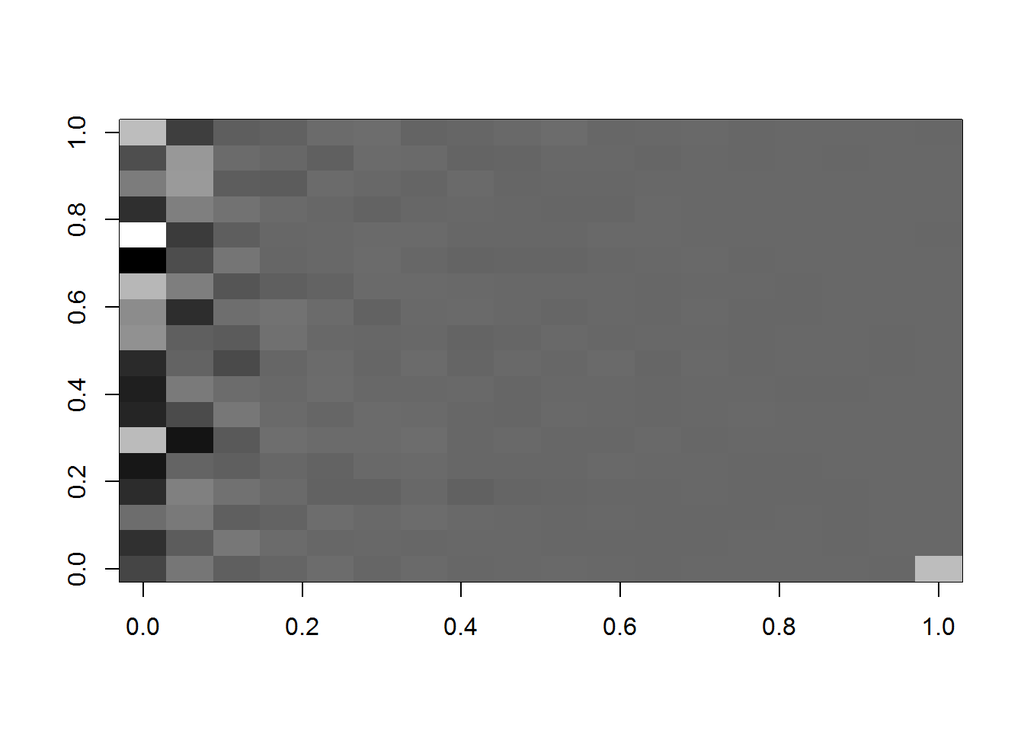

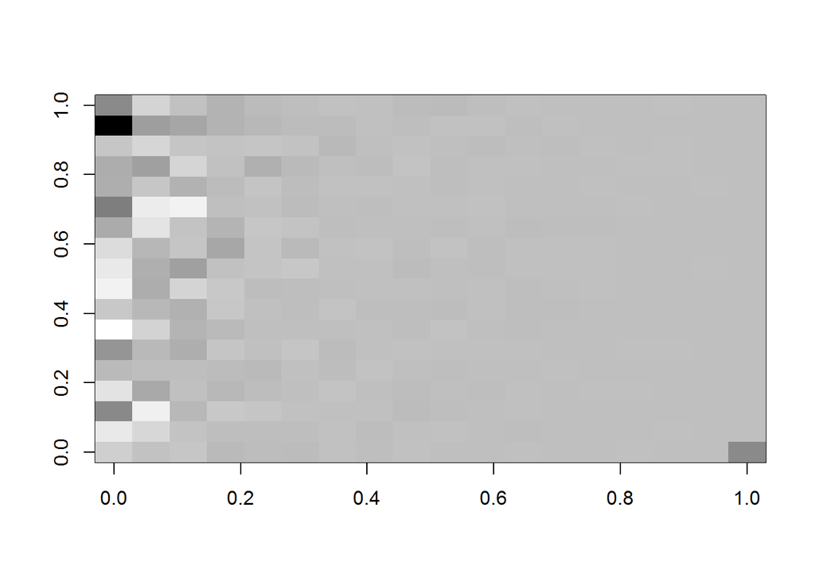

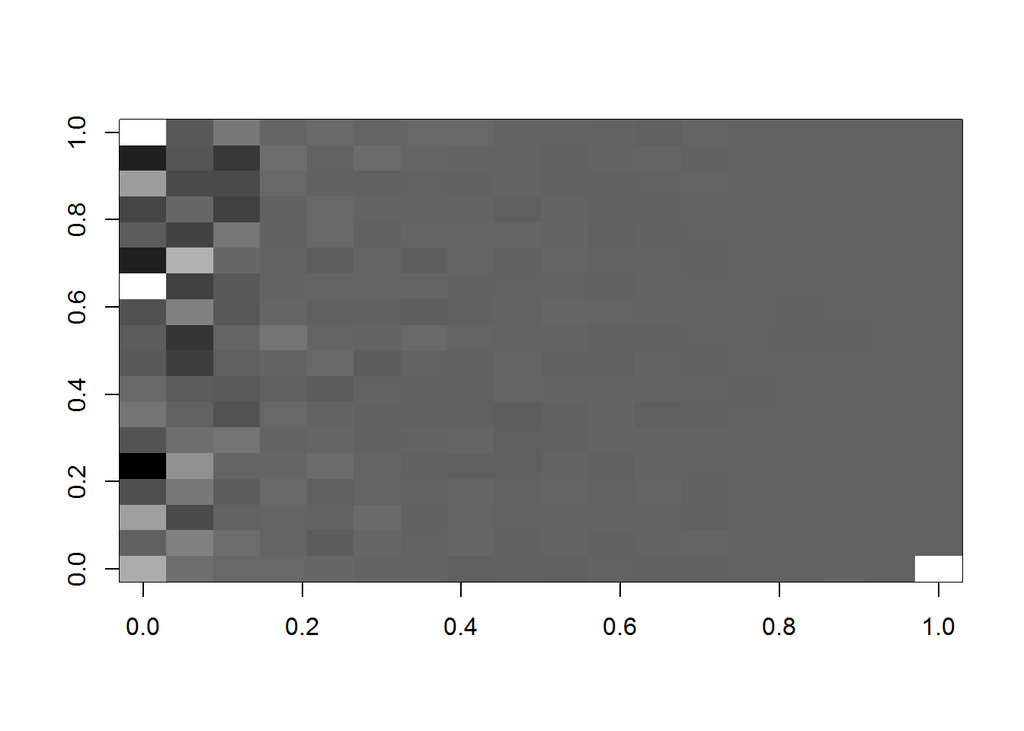

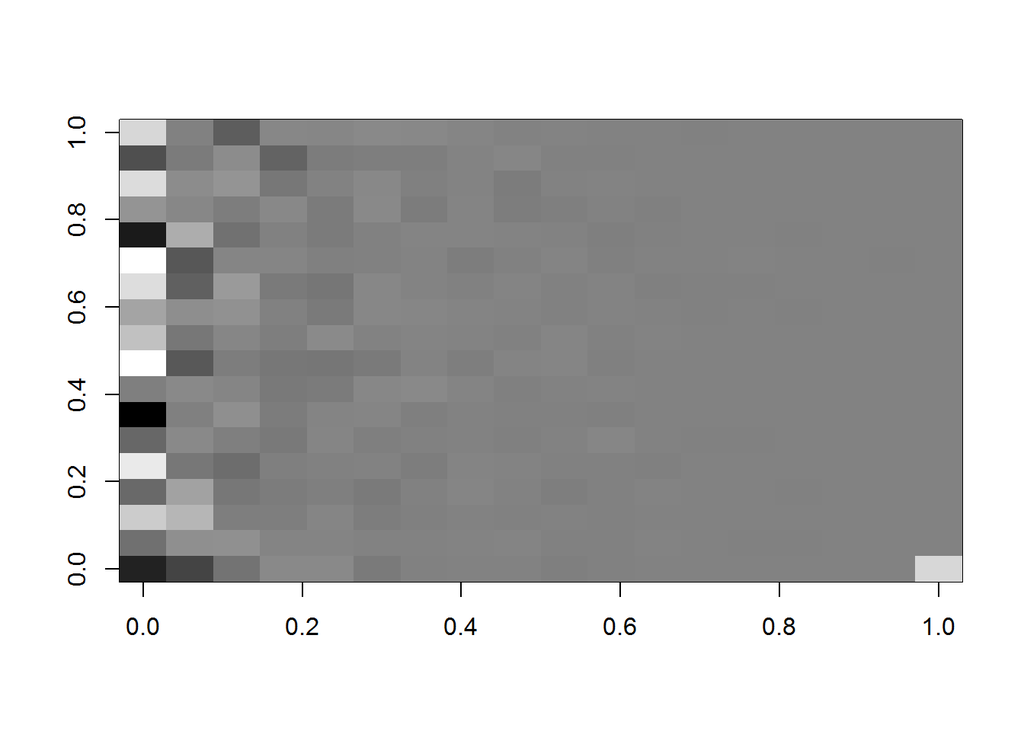

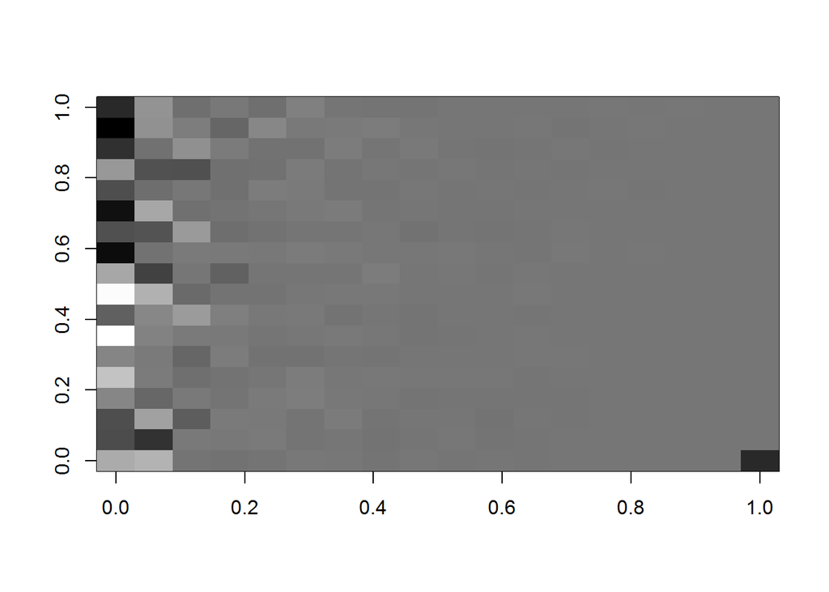

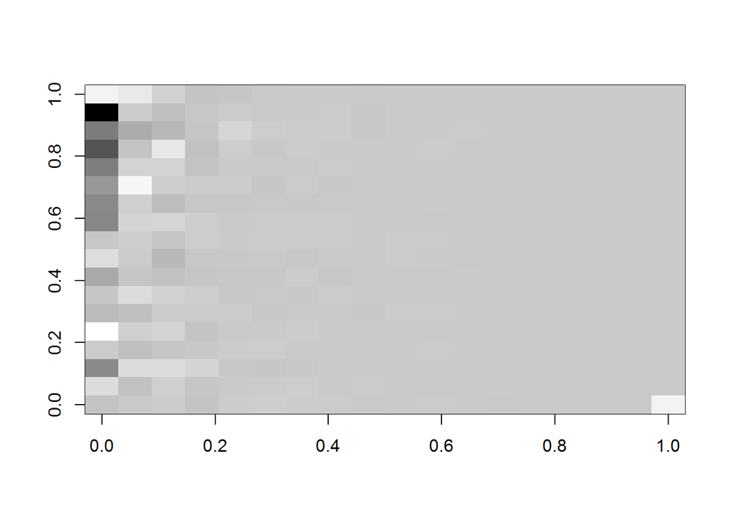

```r
for (i in 1:10){
  imageSize = 18
  imageMatrix <- matrix( p1_pca$x[i*399+i,1:nrow(p1_pca$rotation)-1], nrow = imageSize, ncol=imageSize, byrow= FALSE)
  imageMatrix <- rotate(imageMatrix, 270)
  image(imageMatrix, col=gray((0:255)/255))

}
```

To be honest, i have no idea what’s happening here, or if i’m doing it right but i’m guessing it’s PCA trying to do it’s own thing